# Exam 1 Output Packet

```r
pacman::p_load(DataExplorer, tidyverse, caret, skimr, ROCR, pROC, fastDummies)
```

```r
head(df)
```

```
##   age        workclass education-num     marital-status        occupation
## 1  39        State-gov            13      Never-married      Adm-clerical
## 2  50 Self-emp-not-inc            13 Married-civ-spouse   Exec-managerial
## 3  38          Private             9           Divorced Handlers-cleaners
## 4  53          Private             7 Married-civ-spouse Handlers-cleaners
## 5  28          Private            13 Married-civ-spouse    Prof-specialty
## 6  37          Private            14 Married-civ-spouse   Exec-managerial
##    relationship  race    sex capital-gain capital-loss hours-per-week
## 1 Not-in-family White   Male         2174            0             40
## 2       Husband White   Male            0            0             13
## 3 Not-in-family White   Male            0            0             40
## 4       Husband Black   Male            0            0             40
## 5          Wife Black Female            0            0             40
## 6          Wife White Female            0            0             40
##   native-country income
## 1  United-States  small
## 2  United-States  small
## 3  United-States  small
## 4  United-States  small
## 5           Cuba  small
## 6  United-States  small
```

## Part 1: Perpare Data for Modeling

### Data Summary

Here is a summary of the target variable.

```r
prop.table(table(df$income))
```

```
##
##      small      large
## 0.96111975 0.03888025
```

```r
table(df$income)
```

```
##
## small large
## 24720  1000
```

Here is a summary of the data:

Data summary

| Name | df |
| --- | --- |
| Number of rows | 25720 |
| Number of columns | 13 |
| _______________________ |  |
| Column type frequency: |  |
| factor | 8 |
| numeric | 5 |
| ________________________ |  |
| Group variables | None |

**Variable type: factor**

| skim_variable | n_missing | complete_rate | ordered | n_unique | top_counts |
| --- | --- | --- | --- | --- | --- |
| workclass | 1669 | 0.94 | FALSE | 8 | Pri: 18376, Sel: 1902, Loc: 1535, Sta: 996 |
| marital-status | 0 | 1.00 | FALSE | 7 | Nev: 10251, Mar: 9151, Div: 4028, Sep: 969 |
| occupation | 1676 | 0.93 | FALSE | 14 | Adm: 3324, Cra: 3290, Oth: 3180, Sal: 2810 |
| relationship | 0 | 1.00 | FALSE | 6 | Hus: 8027, Not: 7548, Own: 5007, Unm: 3257 |
| race | 0 | 1.00 | FALSE | 5 | Whi: 21602, Bla: 2790, Asi: 804, Ame: 277 |
| sex | 0 | 1.00 | FALSE | 2 | Mal: 15966, Fem: 9754 |
| native-country | 461 | 0.98 | FALSE | 41 | Uni: 22901, Mex: 616, Phi: 143, Pue: 102 |
| income | 0 | 1.00 | TRUE | 2 | sma: 24720, lar: 1000 |

**Variable type: numeric**

| skim_variable | n_missing | complete_rate | mean | sd | p0 | p25 | p50 | p75 | p100 |
| --- | --- | --- | --- | --- | --- | --- | --- | --- | --- |
| age | 0 | 1 | 37.07 | 13.96 | 17 | 26 | 35 | 46 | 90 |
| education-num | 0 | 1 | 9.67 | 2.46 | 1 | 9 | 9 | 11 | 16 |
| capital-gain | 0 | 1 | 281.43 | 2885.24 | 0 | 0 | 0 | 0 | 99999 |
| capital-loss | 0 | 1 | 59.06 | 328.54 | 0 | 0 | 0 | 0 | 4356 |
| hours-per-week | 0 | 1 | 39.10 | 12.33 | 1 | 36 | 40 | 40 | 99 |

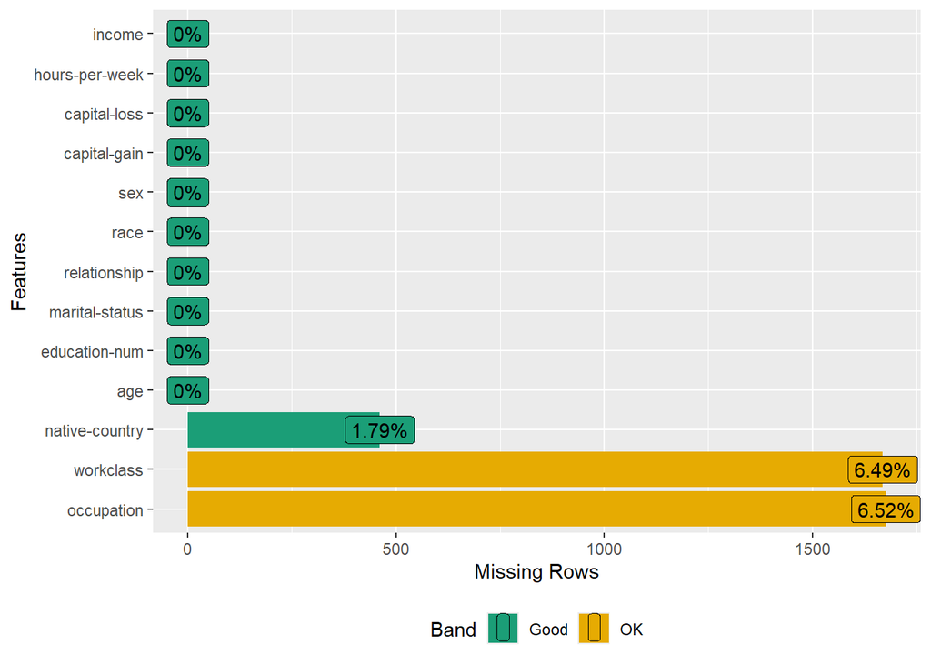

```r
plot_missing(df)
```

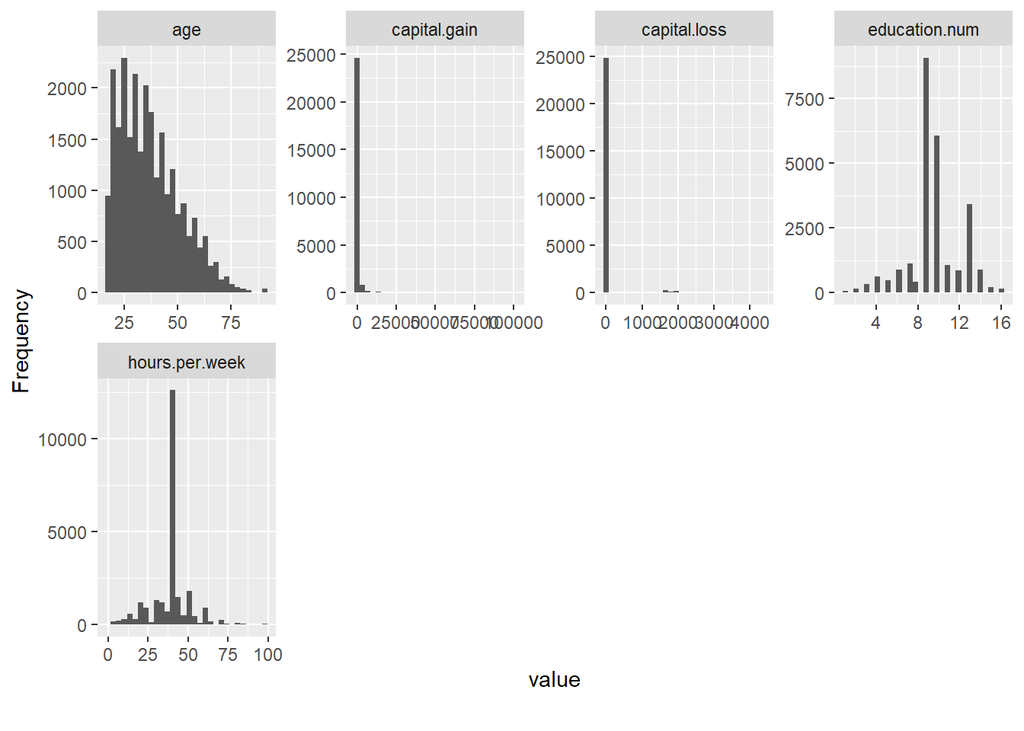

```r
plot_histogram(df)
```

### Categorical Data Preperation

Here is a summary of the native-country variable.

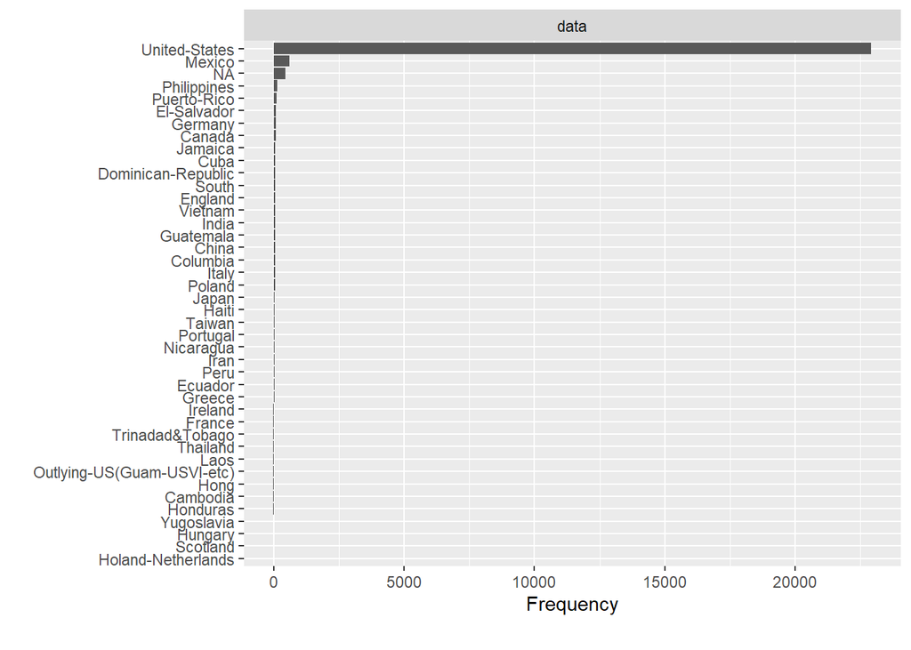

```r
plot_bar(df$`native-country`)
```

Dummy variables were created.

```r
df<-dummy_columns(df, select_columns = c("workclass", "marital-status", "occupation", "relationship", "race", "sex"), remove_first_dummy = TRUE, remove_selected_columns = TRUE)
```

Summary of `marital-status_Married-AF-spouse`.

```r
summary(as.factor(df$`marital-status_Married-AF-spouse`))
```

```
##     0     1
## 25707    13
```

### Partitioning and Over-Sampling

Here are the proportions for the validation data set.

```r
set.seed(13)
trainIndex<-caret::createDataPartition(df$income, p=0.8, list=FALSE, times=1)
head(trainIndex)
```

```
##      Resample1
## [1,]         1
## [2,]         2
## [3,]         3
## [4,]         4
## [5,]         5
## [6,]         6
```

```r
valid<-df[-trainIndex,]
```

```r
prop.table(table(valid$income))
```

```
##
##      small      large
## 0.95974576 0.04025424
```

```r
dim(valid)
```

```
## [1] 4720   40
```

Here are the proportions for the training data set.

```r
prop.table(table(training$income))
```

```
##
## small large
##   0.5   0.5
```

## Part 2: Modeling

I constructed two models.

### Compare the models

Model 1

```r
r<-pROC::roc(valid$income, preds, levels=c("small", "large"), direction="<")
r$auc
```

```
## Area under the curve: 0.9016
```

Model 2

```r
r1<-roc(valid$income, preds1, levels=c("small", "large"), direction="<")
r1$auc
```

```
## Area under the curve: 0.8024
```

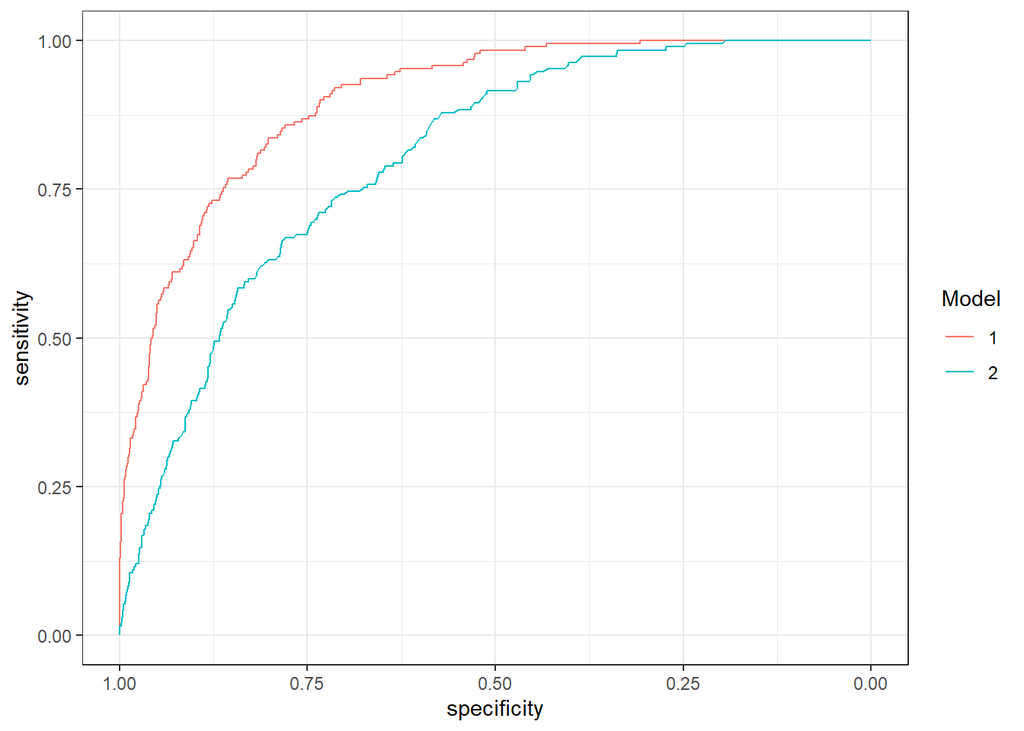

```r
roc<-list(r, r1)
p<-ggroc(roc)+theme_bw()+scale_colour_discrete("Model")
p
```

This is for model 1.

```r
threshold<-coords(r,"best", ret="threshold")
threshold
```

```
##   threshold
## 1  0.527188
```

Here is a summary of the income variable in the validation data.

```r
summary(valid$income)
```

```
## small large
##  4530   190
```

```r
valid$preds<-preds
valid$cut1<-ifelse(valid$preds>threshold$threshold, 'large', 'small')
valid$cut1<-factor(valid$cut1, levels=c("small", "large")) #making sure the levels match up so we are predicting large
caret::confusionMatrix(valid$cut1, valid$income, positive="large")
```

```
## Confusion Matrix and Statistics
##
##           Reference
## Prediction small large
##      small  3634    31
##      large   896   159
##
##                Accuracy : 0.8036
##                  95% CI : (0.792, 0.8149)
##     No Information Rate : 0.9597
##     P-Value [Acc > NIR] : 1
##
##                   Kappa : 0.2009
##
##  Mcnemar's Test P-Value : <2e-16
##
##             Sensitivity : 0.83684
##             Specificity : 0.80221
##          Pos Pred Value : 0.15071
##          Neg Pred Value : 0.99154
##              Prevalence : 0.04025
##          Detection Rate : 0.03369
##    Detection Prevalence : 0.22352
##       Balanced Accuracy : 0.81952
##
##        'Positive' Class : large
##
```

Below is a small summary from a lift analysis for model 1 on the validation data.

```
##       Cutoffs True_Positive Counts
## 96  0.9430429            53     95
## 97  0.9422935            53     96
## 98  0.9417224            53     97
## 99  0.9412763            54     98
## 100 0.9410510            54     99
```

## Part 3: Principal Components Analysis

Let’s pretend we are going to construct a model to predict Class, using only the first 4 columns in the Sonar data (because this is an exam, not real life). And because it is an exam, I conducted principal components analysis.

```r
library(mlbench)
data("Sonar")
Sonar<-Sonar[,1:4]
skim_without_charts(Sonar)
```

Data summary

| Name | Sonar |
| --- | --- |
| Number of rows | 208 |
| Number of columns | 4 |
| _______________________ |  |
| Column type frequency: |  |
| numeric | 4 |
| ________________________ |  |
| Group variables | None |

**Variable type: numeric**

| skim_variable | n_missing | complete_rate | mean | sd | p0 | p25 | p50 | p75 | p100 |
| --- | --- | --- | --- | --- | --- | --- | --- | --- | --- |
| V1 | 0 | 1 | 0.03 | 0.02 | 0.00 | 0.01 | 0.02 | 0.04 | 0.14 |
| V2 | 0 | 1 | 0.04 | 0.03 | 0.00 | 0.02 | 0.03 | 0.05 | 0.23 |
| V3 | 0 | 1 | 0.04 | 0.04 | 0.00 | 0.02 | 0.03 | 0.06 | 0.31 |
| V4 | 0 | 1 | 0.05 | 0.05 | 0.01 | 0.02 | 0.04 | 0.06 | 0.43 |

```r
pca<-prcomp(Sonar,scale=T)
pca$rotation
```

```
##          PC1        PC2        PC3        PC4
## V1 0.4638718  0.6853104  0.5056565 -0.2438937
## V2 0.5244959  0.2658007 -0.5597689  0.5838774
## V3 0.5273907 -0.3233094 -0.3778910 -0.6888603
## V4 0.4812340 -0.5959620  0.5368134  0.3536587
```

```r
head(scale(Sonar))
```

```
##            V1         V2          V3         V4
## 1 -0.39858974 -0.0405504 -0.02686084 -0.7133841
## 2  0.70184499  0.4206156  1.05307772  0.3225521
## 3 -0.12891799  0.5996209  1.71925669  1.1693547
## 4 -0.83354417 -0.6473478  0.48058017 -0.7176825
## 5  2.04585419  0.8544758  0.11105902 -0.3114752
## 6 -0.02452892  0.2082365 -0.41980235 -0.7843091
```

## Part 4: Screen Captures

### File Explorer

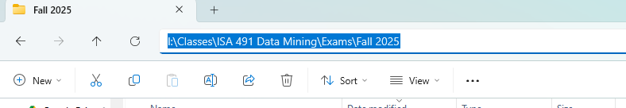

### Enviroment

Here is the environment:

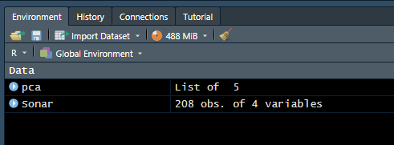

Here is the error:

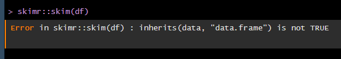

### Code Chunks

I ran them in this order.

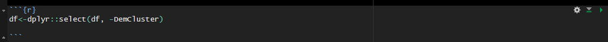

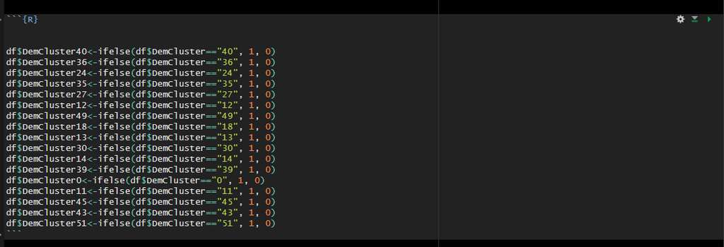

And received this error:

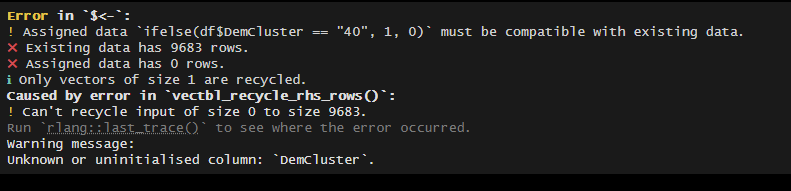

### Table 1

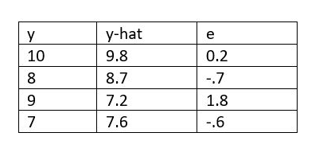

### Table 2

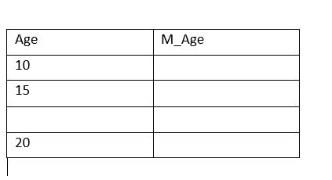

### Table 3

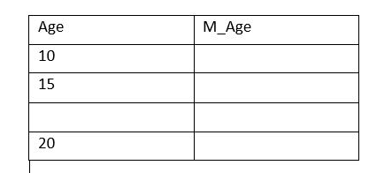